# Source Attribution Analysis for C. jejuni from Southern Alberta, Canada

Other

56

14

2

746

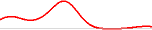

2005

Water

16

8

30

627

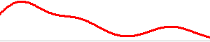

2006

Cattle

53

25

3

746

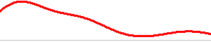

2006

Chicken

83

33

8

746

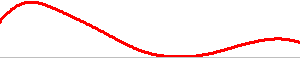

2006

Other

21

7

14

627

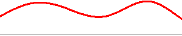

2006

Water

201

44

3

746

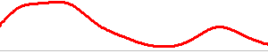

2007

Cattle

16

8

15

459

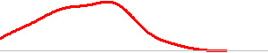

2007

Chicken

67

31

3

746

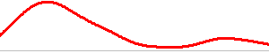

2007

Other

5

5

14

320

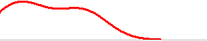

2007

Water

90

22

2

627

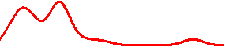

2008

Cattle

458

70

3

746

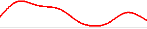

2008

Chicken

46

24

2

746

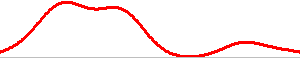

2008

Other

10

6

14

320

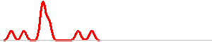

2008

Water

75

30

2

657

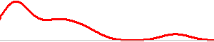

2009

Cattle

1,091

119

1

746

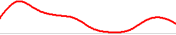

2009

Chicken

87

32

2

746

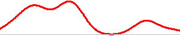

2009

Other

51

20

2

657

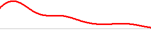

2009

Water

184

31

2

657

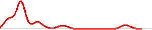

2010

Cattle

332

72

1

746

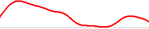

2010

Chicken

221

48

2

746

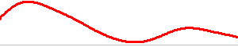

2010

Other

25

12

46

627

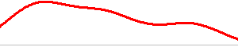

2010

Water

330

46

2

746

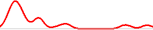

2011

Cattle

295

40

5

746

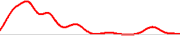

2011

Chicken

188

48

4

746

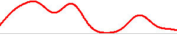

2011

Other

185

35

3

746

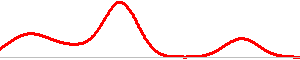

2011

Water

295

42

2

746

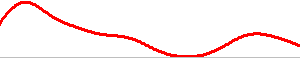

2012

Cattle

468

44

7

746

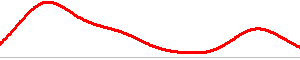

2012

Chicken

553

77

1

746

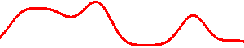

2012

Other

161

16

14

657

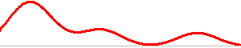

2012

Water

63

19

3

627

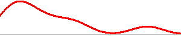

2013

Cattle

384

43

13

746

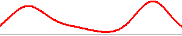

2013

Chicken

1,748

107

2

746

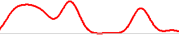

2013

Other

179

22

14

746

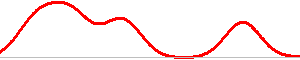

2013

Water

71

18

7

657

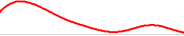

2014

Cattle

834

48

1

746

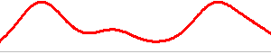

2014

Chicken

111

37

13

746

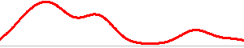

2014

Other

115

29

7

627

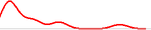

2015

Cattle

775

57

4

746

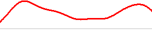

2015

Chicken

141

40

5

746

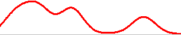

2015

Other

112

20

3

459

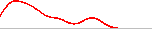

2016

Cattle

376

21

10

746

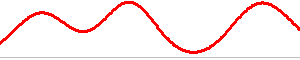

2016

Chicken

179

51

4

746

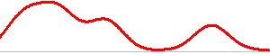

2016

Other

153

18

19

627

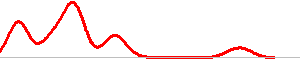

2016

Water

25

12

10

321

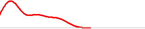

2017

Cattle

42

10

2

657

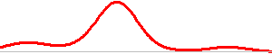

2017

Chicken

150

40

3

746

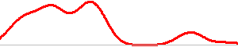

2017

Other

127

35

11

627

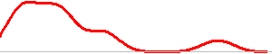

2017

Water

4

2

14

25

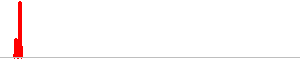

NA

Cattle

6

4

66